# Monitoramento SRAG - Santa Catarina

Bianca Bittencourt

2022-02-28

## Instalação dos pacotes

```r
pacman::p_load(
  tidyverse,         # data management
  stringr,           # work with strings/characters
  lubridate,         # work with dates
  rio,               # import / export
  here,              # relative file paths
  fs)                # directory interactions

library(dplyr)
```

## Exportando o Banco de dados

Os bancos de dados (BD) epidemiológicos de SRAG, da rede de vigilância da Influenza e outros vírus respiratórios, desde o início da sua implantação (2009) até os dias atuais (2022), com a incorporação da vigilância da covid-19. Atualmente, o sistema oficial para o registro dos casos e óbitos por SRAG é o Sistema de Informação da Vigilância Epidemiológica da Gripe (SIVEP-Gripe). Os dados são atualizados uma vez por semana e estão sujeitos a alterações decorrentes da investigação, encerramento das fichas ou mesmo correções de erros de digitação, pelas equipes de vigilância epidemiológica que desenvolvem o serviço nas três esferas de gestão.

1. Para exportar o dataset:

https://opendatasus.saude.gov.br/dataset

1. Para acessar o dicionário de dados:

https://opendatasus.saude.gov.br/dataset/srag-2021-e-2022/resource/3135ac9c-2019-4989-a893-2ed50ebd8e68

1. Para acessar a ficha de notificação:

https://opendatasus.saude.gov.br/dataset/srag-2021-e-2022/resource/9f0edb83-f8c2-4b53-99c1-099425ab634c

## Importando o banco de dados para o Rstudio

Nesse relatório foi utilizado apenas o BD referente as SRAGs notificadas no ano de 2022.

```r
caminho <- here::here("dados", "INFLUD22-21-02-2022.csv")
sivep <- readr::read_csv2(caminho)
```

## Limpeza e tratamento do banco de dados

Para verificar as variáveis presentes no BD utilizando a função `names` seguido do nome do DB.

```r
names (sivep)
```

```
##   [1] "DT_NOTIFIC" "SEM_NOT"    "DT_SIN_PRI" "SEM_PRI"    "SG_UF_NOT"
##   [6] "ID_REGIONA" "CO_REGIONA" "ID_MUNICIP" "CO_MUN_NOT" "ID_UNIDADE"
##  [11] "CO_UNI_NOT" "CS_SEXO"    "DT_NASC"    "NU_IDADE_N" "TP_IDADE"
##  [16] "COD_IDADE"  "CS_GESTANT" "CS_RACA"    "CS_ESCOL_N" "ID_PAIS"
##  [21] "CO_PAIS"    "SG_UF"      "ID_RG_RESI" "CO_RG_RESI" "ID_MN_RESI"
##  [26] "CO_MUN_RES" "CS_ZONA"    "SURTO_SG"   "NOSOCOMIAL" "AVE_SUINO"
##  [31] "FEBRE"      "TOSSE"      "GARGANTA"   "DISPNEIA"   "DESC_RESP"
##  [36] "SATURACAO"  "DIARREIA"   "VOMITO"     "OUTRO_SIN"  "OUTRO_DES"
##  [41] "PUERPERA"   "FATOR_RISC" "CARDIOPATI" "HEMATOLOGI" "SIND_DOWN"
##  [46] "HEPATICA"   "ASMA"       "DIABETES"   "NEUROLOGIC" "PNEUMOPATI"
##  [51] "IMUNODEPRE" "RENAL"      "OBESIDADE"  "OBES_IMC"   "OUT_MORBI"
##  [56] "MORB_DESC"  "VACINA"     "DT_UT_DOSE" "MAE_VAC"    "DT_VAC_MAE"
##  [61] "M_AMAMENTA" "DT_DOSEUNI" "DT_1_DOSE"  "DT_2_DOSE"  "ANTIVIRAL"
##  [66] "TP_ANTIVIR" "OUT_ANTIV"  "DT_ANTIVIR" "HOSPITAL"   "DT_INTERNA"
##  [71] "SG_UF_INTE" "ID_RG_INTE" "CO_RG_INTE" "ID_MN_INTE" "CO_MU_INTE"
```

[output cut: 18 more lines]

### Selecionando os dados referente ao Estado de Santa Catarina

Primeiro é necesário criar uma variável nova chamada de `munres`a partir da variável original `CO_MUN_RES` e simultaneamente reduzir o numero de algarismos para que a variável fique identica ao código do IBGE (6 digitos). Depois criamos uma segunda variável nomeada como `ufres` apenas com os dois primeiros algarismos de forma que seja possível filtrar para a UF de interesse

```r
sivep$munres <- substr(sivep$CO_MUN_RES,1,6)
sivep$ufres <- substr(sivep$munres,1,2)
```

### Filtrando apenas para Santa Catarina

O comando abaixo filtra apenas para as notificações em Santa Catarina (código 42).

```r
sivep <- sivep[sivep[, "ufres"]== 42,]
```

### Criar uma variável de contagem

```r
sivep$count <- 1
```

### Transformando os campos de datas

As datas precisam ser transformadas para o formato de data porque no BD original elas estão salvas como variável de texto.

```r
sivep$dt_sint <- as.Date(sivep$DT_SIN_PRI,format="%d/%m/%Y")
sivep$dt_nasc <- as.Date(sivep$DT_NASC,format="%d/%m/%Y")
sivep$dt_obito <- as.Date(sivep$DT_EVOLUCA,format="%d/%m/%Y")
sivep$dt_interna <- as.Date(sivep$DT_INTERNA,format="%d/%m/%Y")
sivep$dt_notifica <- as.Date(sivep$DT_NOTIFIC,format="%d/%m/%Y")
sivep$dt_vacina1<- as.Date(sivep$DOSE_1_COV,format="%d/%m/%Y")
sivep$dt_vacina2<- as.Date(sivep$DOSE_2_COV,format="%d/%m/%Y")
```

### Criando grupos por estrato de idade

Criando uma variável nova chamada *idade*.

Transformar a variável `NU_IDADE_N`` uma variável numérica com o `as.numeric`.

```r
sivep$NU_IDADE_N <- as.numeric(sivep$NU_IDADE_N)
sivep$idade <- ifelse(sivep$TP_IDADE == 3, sivep$NU_IDADE_N, 0)
```

O passo seguinte é transformar a *idade* em categorias. Vamos criar duas categorizações:

1. A cada 10 anos:

```r
sivep$fxetar=8
sivep[which(sivep$idade >=0 & sivep$idade<=9),]$fxetar=1
sivep[which(sivep$idade>=10 & sivep$idade<=19),]$fxetar=2
sivep[which(sivep$idade>=20 & sivep$idade<=29),]$fxetar=3
sivep[which(sivep$idade>=30 & sivep$idade<=39),]$fxetar=4
sivep[which(sivep$idade>=40 & sivep$idade<=49),]$fxetar=5
sivep[which(sivep$idade>=50 & sivep$idade<=59),]$fxetar=6
sivep[which(sivep$idade>=60 & sivep$idade<=69),]$fxetar=7
sivep[which(sivep$idade>=70 & sivep$idade<130),]$fxetar=8

sivep$fxetar=factor(sivep$fxetar,levels=c(1:8),labels=c("0-9","10-19","20-29","30-39","40-49","50-59","60-69","70+"))
```

2. Conforme a estratificação de priorização vacinal:

```r
sivep$idade_cat=10
sivep[which(sivep$idade >=0 & sivep$idade<=4),]$idade_cat=1
sivep[which(sivep$idade>=5 & sivep$idade<=11),]$idade_cat=2
sivep[which(sivep$idade>=12 & sivep$idade<=17),]$idade_cat=3
sivep[which(sivep$idade>=18 & sivep$idade<=29),]$idade_cat=4
sivep[which(sivep$idade>=30 & sivep$idade<=39),]$idade_cat=5
sivep[which(sivep$idade>=40 & sivep$idade<=49),]$idade_cat=6
sivep[which(sivep$idade>=50 & sivep$idade<=59),]$idade_cat=7
sivep[which(sivep$idade>=60 & sivep$idade<=69),]$idade_cat=8
sivep[which(sivep$idade>=70 & sivep$idade<=79),]$idade_cat=9
sivep[which(sivep$idade>=80 & sivep$idade<110),]$idade_cat=10


sivep$idade_cat=factor(sivep$idade_cat,levels=c(1:10),labels=c("0-4","5-11","12-17","18-29","30-39","40-49","50-59","60-69","70-79", "80+"))
```

### Renomeando os campos de interesse

1. Classificação final

```r
 sivep <- sivep |>
           mutate(classi_final = recode(CLASSI_FIN,
                                        # for reference: OLD = NEW
                                        "1"  = "SRAG por influenza",
                                        "2" = "SRAG por outro vírus  respiratório",
                                        "3"  = "SRAG por outro agente  etiológico",
                                        "4"  = "SRAG não especificado",
                                        "5"   = "SRAG por covid-19"))
```

2. Raça

```r
         sivep$CS_RACA[sivep$CS_RACA == "1"] <- "Branca"
         sivep$CS_RACA[sivep$CS_RACA == "2"] <- "Preta"
         sivep$CS_RACA[sivep$CS_RACA == "3"] <- "Amarela"
         sivep$CS_RACA[sivep$CS_RACA == "4"] <- "Parda"
         sivep$CS_RACA[sivep$CS_RACA == "5"] <- "Indigena"
         sivep$CS_RACA[sivep$CS_RACA == "9"] <- "Ignorado"
```

3. Escolaridade

```r
         sivep$escola[sivep$CS_ESCOL_N == "0"] <- "Sem escolaridade/Analfabeto"
         sivep$escola[sivep$CS_ESCOL_N == "1"] <- "Fundamental 1o ciclo (1 a 5 série)"
         sivep$escola[sivep$CS_ESCOL_N == "2"] <- "Fundamental 2o ciclo (6 a 9 série)"
         sivep$escola[sivep$CS_ESCOL_N == "3"] <- "Médio (1 ao 3 ano)"
         sivep$escola[sivep$CS_ESCOL_N == "4"] <- "Superior"
         sivep$escola[sivep$CS_ESCOL_N == "5"] <- "Não se aplica"
         sivep$escola[sivep$CS_ESCOL_N == "9"] <- "Ignorado"
```

4. UTI

```r
sivep$uti [sivep$UTI == "1"] <- "SIM"
         sivep$uti [sivep$UTI == "2"] <- "NÃO"
         sivep$uti [sivep$UTI == "9"] <- "IGNORADO"
```

5. Evolução

```r
         sivep$evolucao [sivep$EVOLUCAO == "1"] <- "CURA"
         sivep$evolucao [sivep$EVOLUCAO == "2"] <- "ÓBITO"
         sivep$evolucao [sivep$EVOLUCAO == "3"] <- "ÓBITO POR OUTRAS CAUSAS"
         sivep$evolucao [sivep$EVOLUCAO == "9"] <- "IGNORADO"
```

6. vacina

```r
sivep <- sivep %>%
        mutate(vacina = replace_na(VACINA_COV, "2"))

 sivep <- sivep %>%
        mutate(vacina = recode(VACINA_COV,
                                  # for reference: OLD = NEW
                                  "1" = "Sim",
                                  "2" = "Não"))
```

### Tabela de SRAG

```r
classe_final_srag <- sivep |>
dplyr::count(idade_cat) |>
janitor::adorn_totals()

classe_final_srag |>
  dplyr::rename("Faixa etária"= idade_cat, "Frequência" = n) |>

DT::datatable(classe_final_srag)
```

|  | Faixa etária | Frequência |
| --- | --- | --- |
| 1 | 0-4 | 525 |
| 2 | 5-11 | 126 |
| 3 | 12-17 | 97 |
| 4 | 18-29 | 451 |
| 5 | 30-39 | 398 |
| 6 | 40-49 | 455 |
| 7 | 50-59 | 722 |
| 8 | 60-69 | 999 |
| 9 | 70-79 | 1165 |
| 10 | 80+ | 1250 |

[output cut: 1 more lines]

### Tabela Sexo por faixa etária

Uma tabulação cruzada ajustada para que tanto as contagens quanto as porcentagens sejam exibidas.

```r
library(janitor)

sivep %>%                                  # case linelist
  tabyl(idade_cat, CS_SEXO) %>%                  # cross-tabulate counts
  adorn_totals(where = "row") %>%             # add a total row
  adorn_percentages(denominator = "col") %>%  # convert to proportions
  adorn_pct_formatting() %>%                  # convert to percents
  adorn_ns(position = "front") %>%            # display as: "count (percent)"
  adorn_title(                                # adjust titles
    row_name = "Faixa etária",
    col_name = "Sexo")
```

```
##                        Sexo
##  Faixa etária             F             M         NA_
##           0-4  215   (7.0%)  310  (10.1%)  0   (0.0%)
##          5-11   53   (1.7%)   73   (2.4%)  0   (0.0%)
##         12-17   53   (1.7%)   44   (1.4%)  0   (0.0%)
##         18-29  320  (10.4%)  131   (4.3%)  0   (0.0%)
##         30-39  243   (7.9%)  155   (5.0%)  0   (0.0%)
##         40-49  236   (7.7%)  219   (7.1%)  0   (0.0%)
##         50-59  317  (10.3%)  405  (13.2%)  0   (0.0%)
##         60-69  445  (14.4%)  554  (18.0%)  0   (0.0%)
##         70-79  528  (17.1%)  637  (20.7%)  0   (0.0%)
##           80+  670  (21.8%)  550  (17.9%) 30 (100.0%)
##         Total 3080 (100.0%) 3078 (100.0%) 30 (100.0%)
```

### Gráfico Hospitalizados

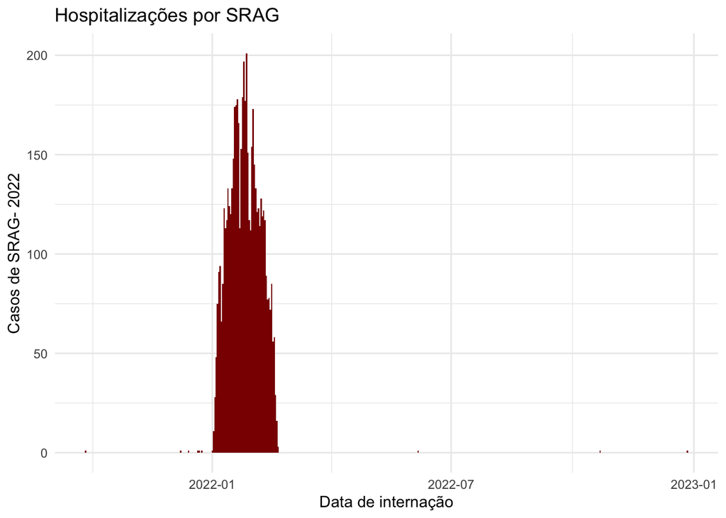

```r
library(ggplot2)

ggplot(sivep, aes(x = dt_interna, y = count)) +
  geom_col(fill = "darkred", width = 1) +
  theme_minimal()+
  labs(
    x = "Data de internação",
    y = "Casos de SRAG- 2022",
    title = "Hospitalizações por SRAG"
  )
```

Gráfico por classificação final

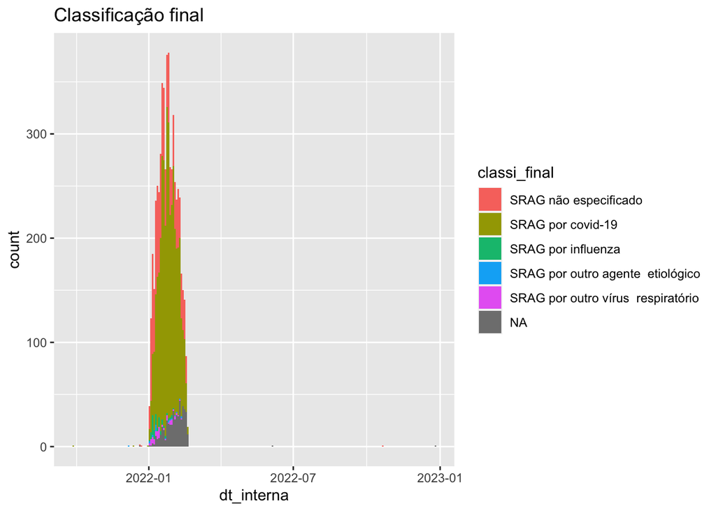

```r
ggplot(data = sivep, mapping = aes(x = dt_interna, fill = classi_final)) +
  geom_histogram(binwidth = 2)+
  labs(title = "Classificação final")
```

### Criar o dataframe para COVID-19

Para criar um banco somente com os casos de covid-19 os casos com classificação final para COVID-19 usar a variável `CLASSI_FIN`

```r
covid <- sivep |>
  filter(classi_final== "SRAG por covid-19" & dt_interna > "2022-01-01")
```

### Tabelas por idade e sexo dos casos de Covid-19

```r
covid %>%                                  # case linelist
  tabyl(idade_cat, CS_SEXO) %>%                  # cross-tabulate counts
  adorn_totals(where = "row") %>%             # add a total row
  adorn_percentages(denominator = "col") %>%  # convert to proportions
  adorn_pct_formatting() %>%                  # convert to percents
  adorn_ns(position = "front") %>%            # display as: "count (percent)"
  adorn_title(                                # adjust titles
    row_name = "Faixa etária",
    col_name = "Sexo")
```

```
##                        Sexo
##  Faixa etária             F             M
##           0-4   63   (3.6%)   81   (4.4%)
##          5-11   17   (1.0%)   23   (1.3%)
##         12-17   21   (1.2%)   14   (0.8%)
##         18-29  195  (11.0%)   65   (3.6%)
##         30-39  145   (8.2%)   95   (5.2%)
##         40-49  131   (7.4%)  150   (8.2%)
##         50-59  189  (10.7%)  259  (14.2%)
##         60-69  275  (15.5%)  346  (19.0%)
##         70-79  321  (18.1%)  416  (22.8%)
##           80+  417  (23.5%)  372  (20.4%)
##         Total 1774 (100.0%) 1821 (100.0%)
```

### Gráfico série temporal de hospitalizados por COVID-19 em 2022.

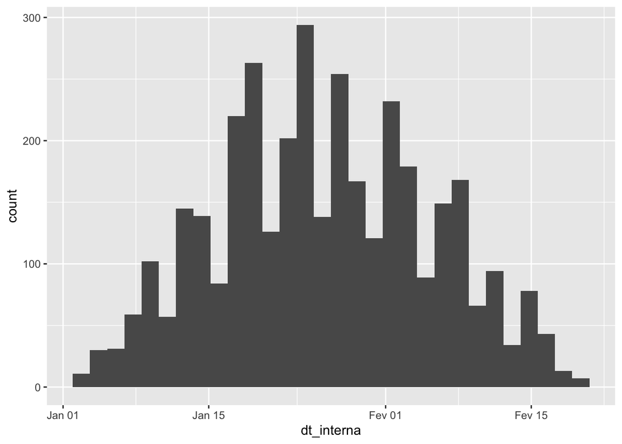

```r
ggplot(data = covid)+
  geom_histogram(aes(x = dt_interna))
```